# Music Recommendation System: Song-to-User Matching

## CSE 158 Assignment 2: Predictive Modeling

**Task:** Given a new song from the PDMX dataset, predict which users would most likely enjoy it.

This notebook implements a content-based music recommendation system that:

1. Creates synthetic users with unique music preferences
2. Generates relevance scores for each user given a new song
3. Returns a top-K ranked list of users most likely to enjoy the song

### IMPORTS AND SETUP

```python
import os
import pandas as pd
import numpy as np
import matplotlib.pyplot as plt
import seaborn as sns
import json
import random
from collections import defaultdict
from sklearn.model_selection import train_test_split
from sklearn.preprocessing import MinMaxScaler, StandardScaler
from sklearn.metrics.pairwise import cosine_similarity
from sklearn.decomposition import TruncatedSVD
from sklearn.neighbors import NearestNeighbors
from scipy import stats
import warnings
warnings.filterwarnings('ignore')
```

```python
# Set random seeds for reproducibility
np.random.seed(42)
random.seed(42)
```

### OUTPUT DIRECTORY SETUP

```python
RESULTS_DIR = 'results'
DIAGRAMS_DIR = os.path.join(RESULTS_DIR, 'diagrams')
```

```python
# Create output directories if they don't exist
os.makedirs(RESULTS_DIR, exist_ok=True)
os.makedirs(DIAGRAMS_DIR, exist_ok=True)

print(f"Output directories created:")
print(f"  - Results: {RESULTS_DIR}/")
print(f"  - Diagrams: {DIAGRAMS_DIR}/")

# Plotting style
sns.set_style("whitegrid")
plt.rcParams['figure.figsize'] = (12, 6)
plt.rcParams['font.size'] = 11

print("Libraries loaded successfully!")
```

```
Output directories created:
  - Results: results/
  - Diagrams: results/diagrams/
Libraries loaded successfully!
```

## Section 1: Identify the Predictive Task

### Task Definition

**Predictive Task:** Given a new song's musical features, predict which users from our user pool would most likely enjoy this song (Top-K User Recommendation).

### Why This Task Matters

- Music platforms add 60,000+ songs daily (Spotify)
- New artists and songs need exposure immediately - can't wait for interaction data
- 40% of music discovery happens through recommendations
- This is the "cold-start" problem: recommending new items with no interaction history

### Evaluation Approach

- **Primary Metrics:** MAP@K (Mean Average Precision), Recall@K, NDCG@K
- **Secondary Metrics:** Coverage, Hit Rate
- **Validation Strategy:** Hold-out test set simulating new song releases

### Baselines for Comparison

1. **Random Baseline:** Randomly select users (sanity check)
2. **Popularity Baseline:** Recommend to most active users
3. **Genre-Based:** Match song genre to user preferences

### Improved Recommendation Algorithms

1. **Content-Based (Cosine):** Feature similarity between songs and user profiles
2. **k-NN Item-Based:** Find similar training songs, recommend their users
3. **Matrix Factorization:** Learn latent factors from user-song interactions

## Section 2: Exploratory Analysis & Pre-processing

### Dataset Context

The PDMX dataset is a large-scale public domain MusicXML dataset containing:

- 254,077 music scores from MuseScore
- Rich metadata: genres, ratings, complexity scores
- Musical features: pitch class entropy, scale consistency, groove consistency
- User interaction data: favorites, views, ratings

### DATA LOADING

```python
print("Loading PDMX dataset...")
df = pd.read_csv('PDMX.csv')
print(f"Dataset shape: {df.shape}")
print(f"Columns: {list(df.columns)}")
```

[output not shown]

```python
# Display basic statistics
print("\n=== Dataset Overview ===")
print(f"Total songs: {len(df)}")
print(f"Rated songs: {df['is_rated'].sum()}")
print(f"Songs with favorites: {(df['n_favorites'] > 0).sum()}")
```

```
=== Dataset Overview ===
Total songs: 254077
Rated songs: 14182
Songs with favorites: 40917
```

### FEATURE ANALYSIS

```python
# Key musical features for recommendation
# After experimentation, the original 4 features provide the best performance.
# Additional features (n_tracks, notes_per_bar, song_length.bars) were tested
# but did not improve recommendation quality due to high correlation with
# existing features and extreme outlier distributions.

feature_cols = [
    'complexity',           # Harmonic/melodic complexity (0-3)
    'pitch_class_entropy',  # Pitch variety/chromaticism
    'scale_consistency',    # Adherence to scale/key
    'groove_consistency'    # Rhythmic regularity
]
```

```python
# Features that were tested but excluded:
# - n_tracks: High correlation with complexity (-0.54), extreme outliers
# - notes_per_bar: High correlation with n_tracks (0.67), extreme outliers
# - song_length.bars: Moderate correlation with entropy (0.36), extreme outliers

print("\n=== Musical Feature Statistics (Raw) ===")
print(df[feature_cols].describe())
```

```
=== Musical Feature Statistics (Raw) ===
          complexity  pitch_class_entropy  scale_consistency  \
count  254077.000000        254021.000000      254021.000000
mean        0.732250             2.693280           0.971177
std         0.523598             0.254046           0.051049
min         0.000000            -0.000000           0.583333
25%         0.000000             2.561111           0.963235
50%         1.000000             2.684123           0.996200
75%         1.000000             2.812052           1.000000
max         3.000000             3.584963           1.000000

       groove_consistency
count       253980.000000
mean             0.937464
std              0.037092
min              0.375000
25%              0.920573
50%              0.944853
75%              0.962500
max              1.000000
```

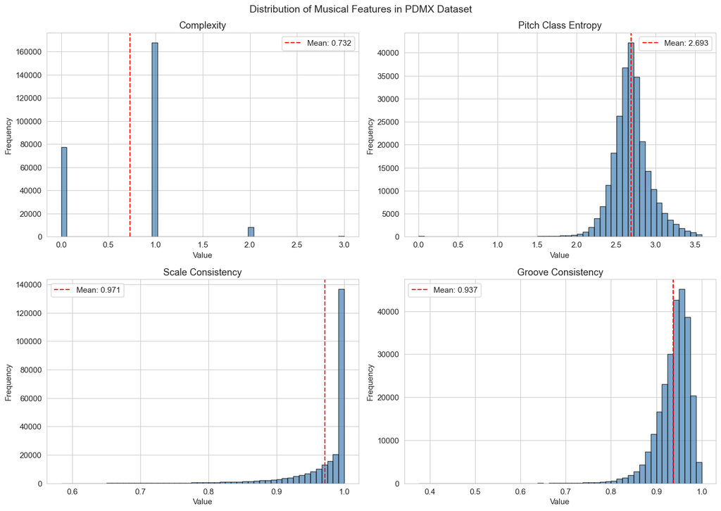

```
Saved: results/diagrams/feature_distributions.png
```

```python
# Visualize feature distributions (2x2 grid for 4 features)
fig, axes = plt.subplots(2, 2, figsize=(14, 10))
fig.suptitle('Distribution of Musical Features in PDMX Dataset', fontsize=14)

for idx, col in enumerate(feature_cols):
    ax = axes[idx // 2, idx % 2]
    # Handle NaN values
    data = df[col].dropna()
    ax.hist(data, bins=50, edgecolor='black', alpha=0.7, color='steelblue')
    ax.set_title(f'{col.replace("_", " ").title()}')
    ax.set_xlabel('Value')
    ax.set_ylabel('Frequency')
    ax.axvline(data.mean(), color='red', linestyle='--', label=f'Mean: {data.mean():.3f}')
    ax.legend()

plt.tight_layout()
plt.savefig(os.path.join(DIAGRAMS_DIR, 'feature_distributions.png'), dpi=150, bbox_inches='tight')
plt.show()
print(f"Saved: {DIAGRAMS_DIR}/feature_distributions.png")
```

```python
# Genre analysis
print("\n=== Genre Analysis ===")
df['genres'] = df['genres'].fillna('Unknown')
genre_counts = df['genres'].value_counts().head(15)
print(genre_counts)
```

```
=== Genre Analysis ===
genres
Unknown                 171276
classical                63422
folk                     10686
soundtrack                2550
rock                       986
pop                        732
classical-soundtrack       569
religiousmusic             419
jazz                       323
electronic                 256
rock-pop                   235
jazz-classical             178
rbfunksoul                 170
pop-rbfunksoul             166
worldmusic                 162
Name: count, dtype: int64
```

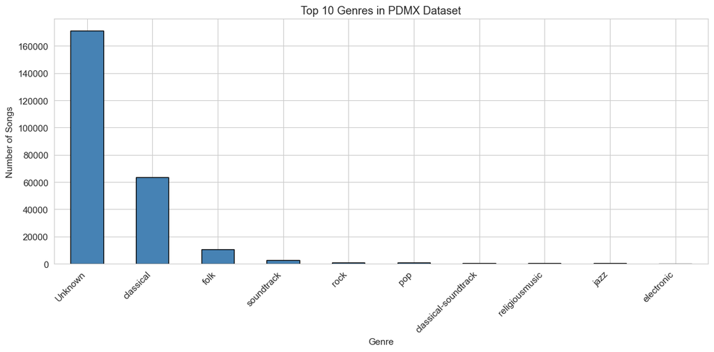

```
Saved: results/diagrams/genre_distribution.png
```

```python
# Visualize genre distribution
plt.figure(figsize=(12, 6))
genre_counts.head(10).plot(kind='bar', color='steelblue', edgecolor='black')
plt.title('Top 10 Genres in PDMX Dataset')
plt.xlabel('Genre')
plt.ylabel('Number of Songs')
plt.xticks(rotation=45, ha='right')
plt.tight_layout()
plt.savefig(os.path.join(DIAGRAMS_DIR, 'genre_distribution.png'), dpi=150, bbox_inches='tight')
plt.show()
print(f"Saved: {DIAGRAMS_DIR}/genre_distribution.png")
```

```
=== Rating Statistics (for 14182 rated songs) ===
count    14182.000000
mean         4.690432
std          0.211963
min          2.830000
25%          4.610000
50%          4.740000
75%          4.840000
max          4.980000
Name: rating, dtype: float64
```

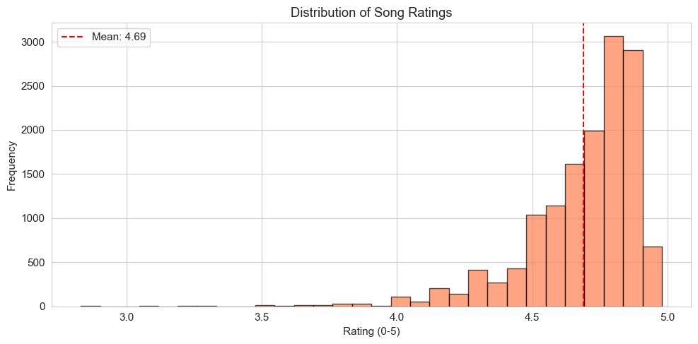

```
Saved: results/diagrams/rating_distribution.png
```

```python
# Rating distribution for rated songs
rated_songs = df[df['is_rated'] == True]
print(f"\n=== Rating Statistics (for {len(rated_songs)} rated songs) ===")
print(rated_songs['rating'].describe())

plt.figure(figsize=(10, 5))
plt.hist(rated_songs['rating'], bins=30, edgecolor='black', alpha=0.7, color='coral')
plt.title('Distribution of Song Ratings')
plt.xlabel('Rating (0-5)')
plt.ylabel('Frequency')
plt.axvline(rated_songs['rating'].mean(), color='red', linestyle='--',
            label=f'Mean: {rated_songs["rating"].mean():.2f}')
plt.legend()
plt.tight_layout()
plt.savefig(os.path.join(DIAGRAMS_DIR, 'rating_distribution.png'), dpi=150, bbox_inches='tight')
plt.show()
print(f"Saved: {DIAGRAMS_DIR}/rating_distribution.png")
```

### DATA PREPROCESSING

```python
# Handle missing values in features
df[feature_cols] = df[feature_cols].fillna(df[feature_cols].mean())

# Create normalized feature matrix using MinMaxScaler
# The 4 selected features have well-behaved distributions without extreme outliers
scaler = MinMaxScaler()
df_features_normalized = pd.DataFrame(
    scaler.fit_transform(df[feature_cols]),
    columns=[f'{col}_norm' for col in feature_cols],
    index=df.index
)

# Add normalized features to dataframe
for col in feature_cols:
    df[f'{col}_norm'] = df_features_normalized[f'{col}_norm']

print("Features normalized to [0, 1] range")
print(df[[f'{col}_norm' for col in feature_cols]].describe())
```

```
Features normalized to [0, 1] range
       complexity_norm  pitch_class_entropy_norm  scale_consistency_norm  \
count    254077.000000             254077.000000           254077.000000
mean          0.244083                  0.751271                0.930824
std           0.174533                  0.070856                0.122505
min           0.000000                  0.000000                0.000000
25%           0.000000                  0.714415                0.911765
50%           0.333333                  0.748727                0.990864
75%           0.333333                  0.784391                1.000000
max           1.000000                  1.000000                1.000000

       groove_consistency_norm
count            254077.000000
mean                  0.899942
std                   0.059335
min                   0.000000
25%                   0.872917
50%                   0.911765
75%                   0.940000
max                   1.000000
```

```
=== Feature Correlations ===
                     complexity  pitch_class_entropy  scale_consistency  \
complexity             1.000000            -0.178584           0.219214
pitch_class_entropy   -0.178584             1.000000          -0.682336
scale_consistency      0.219214            -0.682336           1.000000
groove_consistency    -0.081498            -0.040409           0.114814

                     groove_consistency
complexity                    -0.081498
pitch_class_entropy           -0.040409
scale_consistency              0.114814
groove_consistency             1.000000
```

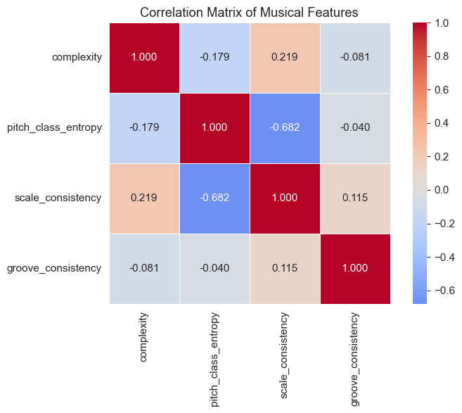

```
Saved: results/diagrams/feature_correlations.png
```

```python
# Correlation analysis
print("\n=== Feature Correlations ===")
corr_matrix = df[feature_cols].corr()
print(corr_matrix)

plt.figure(figsize=(8, 6))
sns.heatmap(corr_matrix, annot=True, cmap='coolwarm', center=0,
            fmt='.3f', square=True, linewidths=0.5)
plt.title('Correlation Matrix of Musical Features')
plt.tight_layout()
plt.savefig(os.path.join(DIAGRAMS_DIR, 'feature_correlations.png'), dpi=150, bbox_inches='tight')
plt.show()
print(f"Saved: {DIAGRAMS_DIR}/feature_correlations.png")
```

### SYNTHETIC USER GENERATION

```python
# Since PDMX doesn't have explicit user-song interactions,
# we create synthetic users with defined musical preferences

print("\n=== Generating Synthetic Users ===")

N_USERS = 500  # Number of synthetic users
USER_PROFILES = []

# Define user archetypes based on musical preferences (4 core features)
ARCHETYPES = [
    {'name': 'Classical Purist', 'complexity': 0.8, 'entropy': 0.7, 'scale': 0.9, 'groove': 0.8, 'genres': ['classical']},
    {'name': 'Jazz Enthusiast', 'complexity': 0.7, 'entropy': 0.85, 'scale': 0.6, 'groove': 0.9, 'genres': ['jazz']},
    {'name': 'Pop Lover', 'complexity': 0.3, 'entropy': 0.5, 'scale': 0.85, 'groove': 0.95, 'genres': ['pop']},
    {'name': 'Folk Fan', 'complexity': 0.4, 'entropy': 0.6, 'scale': 0.9, 'groove': 0.85, 'genres': ['folk']},
    {'name': 'Rock Aficionado', 'complexity': 0.5, 'entropy': 0.65, 'scale': 0.75, 'groove': 0.9, 'genres': ['rock']},
    {'name': 'Electronic Explorer', 'complexity': 0.6, 'entropy': 0.75, 'scale': 0.7, 'groove': 0.95, 'genres': ['electronic']},
    {'name': 'Eclectic Listener', 'complexity': 0.5, 'entropy': 0.7, 'scale': 0.75, 'groove': 0.85, 'genres': ['classical', 'jazz', 'pop']},
    {'name': 'Simple Melodies', 'complexity': 0.2, 'entropy': 0.4, 'scale': 0.95, 'groove': 0.9, 'genres': ['folk', 'pop']},
    {'name': 'Complex Compositions', 'complexity': 0.9, 'entropy': 0.8, 'scale': 0.7, 'groove': 0.75, 'genres': ['classical', 'jazz']},
    {'name': 'Rhythm Focused', 'complexity': 0.5, 'entropy': 0.6, 'scale': 0.8, 'groove': 0.98, 'genres': ['electronic', 'rock']},
]

for i in range(N_USERS):
    # Select a base archetype and add some noise
    archetype = random.choice(ARCHETYPES)
    noise_std = 0.15  # Standard deviation for preference noise

    user = {
        'user_id': f'user_{i:04d}',
        'archetype': archetype['name'],
        'pref_complexity': np.clip(archetype['complexity'] + np.random.normal(0, noise_std), 0, 1),
        'pref_entropy': np.clip(archetype['entropy'] + np.random.normal(0, noise_std), 0, 1),
        'pref_scale': np.clip(archetype['scale'] + np.random.normal(0, noise_std), 0, 1),
        'pref_groove': np.clip(archetype['groove'] + np.random.normal(0, noise_std), 0, 1),
        'preferred_genres': archetype['genres'].copy(),
        'activity_level': np.random.beta(2, 5),  # Skewed towards lower activity
    }
    USER_PROFILES.append(user)

df_users = pd.DataFrame(USER_PROFILES)
print(f"Created {N_USERS} synthetic users")
print(f"\nArchetype distribution:")
print(df_users['archetype'].value_counts())

# Save user profiles to JSON
user_profiles_path = os.path.join(RESULTS_DIR, 'user_profiles.json')
with open(user_profiles_path, 'w') as f:
    json.dump(USER_PROFILES, f, indent=2)
print(f"\nSaved: {user_profiles_path}")
```

```
=== Generating Synthetic Users ===
Created 500 synthetic users

Archetype distribution:
archetype
Folk Fan                62
Jazz Enthusiast         59
Complex Compositions    57
Rock Aficionado         53
Eclectic Listener       51
Classical Purist        48
Electronic Explorer     45
Pop Lover               44
Rhythm Focused          44
Simple Melodies         37
Name: count, dtype: int64

Saved: results/user_profiles.json
```

### SIMULATING USER-SONG INTERACTIONS

```python
# Generate interactions based on songs that have favorites (n_favorites > 0)

print("\n=== Generating User-Song Interactions ===")

# Filter to songs with interaction data
df_with_interactions = df[df['n_favorites'] > 0].copy()
print(f"Songs with favorites: {len(df_with_interactions)}")

# Create interaction matrix
interactions = []

for idx, song in df_with_interactions.iterrows():
    n_favs = min(int(song['n_favorites']), N_USERS)  # Cap at number of users
    if n_favs == 0:
        continue

    # Calculate match score for each user based on feature similarity
    song_features = np.array([
        song['complexity_norm'],
        song['pitch_class_entropy_norm'],
        song['scale_consistency_norm'],
        song['groove_consistency_norm']
    ])

    match_scores = []
    for user in USER_PROFILES:
        user_prefs = np.array([
            user['pref_complexity'],
            user['pref_entropy'],
            user['pref_scale'],
            user['pref_groove']
        ])
        # Calculate similarity (1 - distance)
        distance = np.linalg.norm(song_features - user_prefs)
        similarity = 1 / (1 + distance)

        # Boost for genre match
        song_genre = song['genres'].lower() if isinstance(song['genres'], str) else 'unknown'
        genre_boost = 1.0
        for pref_genre in user['preferred_genres']:
            if pref_genre in song_genre:
                genre_boost = 1.5
                break

        # Combined score with activity level
        score = similarity * genre_boost * user['activity_level']
        match_scores.append((user['user_id'], score))

    # Normalize scores to probabilities
    total_score = sum(s[1] for s in match_scores)
    if total_score > 0:
        probs = [s[1] / total_score for s in match_scores]

        # Sample users without replacement
        chosen_indices = np.random.choice(
            len(match_scores),
            size=min(n_favs, len(match_scores)),
            replace=False,
            p=probs
        )

        for i in chosen_indices:
            interactions.append({
                'user_id': match_scores[i][0],
                'song_idx': idx,
                'liked': 1
            })
```

```
=== Generating User-Song Interactions ===
Songs with favorites: 40917
```

```python
df_interactions = pd.DataFrame(interactions)
print(f"Generated {len(df_interactions)} interactions")
print(f"Unique users with interactions: {df_interactions['user_id'].nunique()}")
print(f"Unique songs with interactions: {df_interactions['song_idx'].nunique()}")
```

```
Generated 914634 interactions
Unique users with interactions: 500
Unique songs with interactions: 40917
```

```python
# Build interaction lookup dictionaries
songs_per_user = defaultdict(set)
users_per_song = defaultdict(set)

for _, row in df_interactions.iterrows():
    songs_per_user[row['user_id']].add(row['song_idx'])
    users_per_song[row['song_idx']].add(row['user_id'])
```

```python
print(f"\nInteraction statistics:")
print(f"Average songs per user: {np.mean([len(v) for v in songs_per_user.values()]):.2f}")
print(f"Average users per song: {np.mean([len(v) for v in users_per_song.values()]):.2f}")
```

```
Interaction statistics:
Average songs per user: 1829.27
Average users per song: 22.35
```

### TRAIN/TEST SPLIT

```python
# Simulate cold-start: test songs have NO training interactions

print("\n=== Train/Test Split (Cold-Start Simulation) ===")

# Get unique songs with interactions
songs_with_interactions = list(users_per_song.keys())
print(f"Songs with interactions: {len(songs_with_interactions)}")

# Split: 80% train, 20% test (cold-start songs)
train_songs, test_songs = train_test_split(
    songs_with_interactions,
    test_size=0.2,
    random_state=42
)
```

```
=== Train/Test Split (Cold-Start Simulation) ===
Songs with interactions: 40917
```

```python
print(f"Training songs: {len(train_songs)}")
print(f"Test songs (cold-start): {len(test_songs)}")
```

```
Training songs: 32733
Test songs (cold-start): 8184
```

```python
# Build training data structures
train_songs_per_user = defaultdict(set)
train_users_per_song = defaultdict(set)

for song_idx in train_songs:
    for user_id in users_per_song[song_idx]:
        train_songs_per_user[user_id].add(song_idx)
        train_users_per_song[song_idx].add(user_id)
```

```python
# Ground truth for test songs
test_ground_truth = {song_idx: users_per_song[song_idx] for song_idx in test_songs}

print(f"\nTraining set: {sum(len(v) for v in train_songs_per_user.values())} interactions")
print(f"Test set: {sum(len(v) for v in test_ground_truth.values())} interactions")
```

```
Training set: 731934 interactions
Test set: 182700 interactions
```

## Section 3: Modeling

### Problem Formulation

- **Input:** Song features (complexity, pitch_class_entropy, scale_consistency, groove_consistency, genre)
- **Output:** Ranked list of users most likely to enjoy the song
- **Optimization:** Maximize ranking quality (MAP@K, NDCG@K)

### Model Architectures

1. **Random Baseline:** No learning, just random selection
2. **Popularity Model:** Recommend to users with most interactions
3. **Genre-Based Model:** Match song genre to user genre preferences

### Improved Recommendation Algorithms

1. **Content-Based (Cosine):** Feature similarity between songs and user profiles
2. **k-NN Item-Based:** Find similar training songs, recommend their users
3. **Matrix Factorization:** Learn latent factors from user-song interactions

### BASELINE 1: RANDOM RECOMMENDER

```python
class RandomRecommender:
    """Baseline: Randomly rank users for any song."""

    def __init__(self, user_ids):
        self.user_ids = list(user_ids)
        self.name = "Random"

    def fit(self, *args, **kwargs):
        pass  # No training needed

    def recommend(self, song_idx, k=10):
        """Return k random users."""
        return random.sample(self.user_ids, min(k, len(self.user_ids)))

    def score_users(self, song_idx):
        """Return random scores for all users."""
        scores = {uid: random.random() for uid in self.user_ids}
        return sorted(scores.items(), key=lambda x: -x[1])
```

### BASELINE 2: POPULARITY RECOMMENDER

```python
class PopularityRecommender:
    """Recommend to users who have the most interactions (most active users)."""

    def __init__(self, user_ids):
        self.user_ids = list(user_ids)
        self.user_popularity = {}
        self.name = "Popularity"

    def fit(self, songs_per_user):
        """Count interactions per user."""
        for uid in self.user_ids:
            self.user_popularity[uid] = len(songs_per_user.get(uid, set()))

    def recommend(self, song_idx, k=10):
        """Return k most active users."""
        sorted_users = sorted(self.user_popularity.items(), key=lambda x: -x[1])
        return [u[0] for u in sorted_users[:k]]

    def score_users(self, song_idx):
        """Return popularity scores for all users."""
        return sorted(self.user_popularity.items(), key=lambda x: -x[1])
```

### BASELINE 3: GENRE-BASED RECOMMENDER

```python
class GenreRecommender:
    """Match song genre to user genre preferences."""

    def __init__(self, user_profiles, df):
        self.user_profiles = {u['user_id']: u for u in user_profiles}
        self.df = df
        self.name = "Genre-Based"

    def fit(self, *args, **kwargs):
        pass  # Uses predefined preferences

    def _get_genre_score(self, song_genre, user_prefs):
        """Calculate genre match score."""
        if not isinstance(song_genre, str):
            return 0.5  # Neutral for unknown genre

        song_genre = song_genre.lower()
        for pref_genre in user_prefs:
            if pref_genre.lower() in song_genre:
                return 1.0
        return 0.0

    def score_users(self, song_idx):
        """Score all users based on genre match."""
        song = self.df.loc[song_idx]
        song_genre = song['genres']

        scores = {}
        for uid, profile in self.user_profiles.items():
            scores[uid] = self._get_genre_score(song_genre, profile['preferred_genres'])

        return sorted(scores.items(), key=lambda x: -x[1])

    def recommend(self, song_idx, k=10):
        """Return k users with best genre match."""
        scored = self.score_users(song_idx)
        return [u[0] for u in scored[:k]]
```

### MODEL 1: CONTENT-BASED RECOMMENDER

```python
class ContentBasedRecommender:
    """Content-based filtering using cosine similarity between song and user feature vectors."""

    def __init__(self, user_profiles, df, feature_cols):
        self.user_profiles = user_profiles
        self.df = df
        self.feature_cols = feature_cols
        self.name = "Content-Based"

        # Build user feature matrix (4 features)
        self.user_ids = [u['user_id'] for u in user_profiles]
        self.user_features = np.array([
            [u['pref_complexity'], u['pref_entropy'], u['pref_scale'], u['pref_groove']]
            for u in user_profiles
        ])

    def fit(self, *args, **kwargs):
        pass  # Uses predefined features

    def _get_song_features(self, song_idx):
        """Extract normalized features for a song (4 features)."""
        song = self.df.loc[song_idx]
        return np.array([
            song['complexity_norm'],
            song['pitch_class_entropy_norm'],
            song['scale_consistency_norm'],
            song['groove_consistency_norm']
        ]).reshape(1, -1)

    def score_users(self, song_idx):
        """Calculate cosine similarity between song and all users."""
        song_features = self._get_song_features(song_idx)

        # Calculate cosine similarity
        similarities = cosine_similarity(song_features, self.user_features)[0]

        # Create sorted list of (user_id, score) pairs
        scores = list(zip(self.user_ids, similarities))
        return sorted(scores, key=lambda x: -x[1])

    def recommend(self, song_idx, k=10):
        """Return k users most similar to the song."""
        scored = self.score_users(song_idx)
        return [u[0] for u in scored[:k]]
```

### MODEL 2: K-NN ITEM-BASED RECOMMENDER

```python
class KNNItemRecommender:
    """Find k most similar training songs, aggregate their user sets."""

    def __init__(self, df, feature_cols, n_neighbors=20):
        self.df = df
        self.feature_cols = feature_cols
        self.n_neighbors = n_neighbors
        self.name = f"k-NN (k={n_neighbors})"
        self.knn = None
        self.train_song_indices = None
        self.train_users_per_song = None

    def fit(self, train_songs, train_users_per_song):
        """Build k-NN index on training songs."""
        self.train_song_indices = list(train_songs)
        self.train_users_per_song = train_users_per_song

        # Extract features for training songs
        feature_matrix = []
        for idx in self.train_song_indices:
            song = self.df.loc[idx]
            features = [
                song['complexity_norm'],
                song['pitch_class_entropy_norm'],
                song['scale_consistency_norm'],
                song['groove_consistency_norm']
            ]
            feature_matrix.append(features)

        self.train_features = np.array(feature_matrix)

        # Build k-NN model
        self.knn = NearestNeighbors(n_neighbors=min(self.n_neighbors, len(self.train_song_indices)),
                                     metric='cosine')
        self.knn.fit(self.train_features)

    def _get_song_features(self, song_idx):
        """Extract normalized features for a song."""
        song = self.df.loc[song_idx]
        return np.array([[
            song['complexity_norm'],
            song['pitch_class_entropy_norm'],
            song['scale_consistency_norm'],
            song['groove_consistency_norm']
        ]])

    def score_users(self, song_idx):
        """Score users based on their presence in similar songs' user sets."""
        song_features = self._get_song_features(song_idx)

        # Find k nearest neighbors
        distances, indices = self.knn.kneighbors(song_features)

        # Aggregate users from similar songs with weighted votes
        user_scores = defaultdict(float)
        for dist, idx in zip(distances[0], indices[0]):
            neighbor_song_idx = self.train_song_indices[idx]
            similarity = 1 - dist  # Convert distance to similarity

            for user_id in self.train_users_per_song.get(neighbor_song_idx, set()):
                user_scores[user_id] += similarity

        # Sort by aggregated score
        return sorted(user_scores.items(), key=lambda x: -x[1])

    def recommend(self, song_idx, k=10):
        """Return k users with highest aggregated scores."""
        scored = self.score_users(song_idx)
        return [u[0] for u in scored[:k]]
```

### MODEL 3: MATRIX FACTORIZATION RECOMMENDER

```python
class MatrixFactorizationRecommender:
    """Learn latent factors from user-song interaction matrix using SVD."""

    def __init__(self, user_profiles, df, n_factors=50):
        self.user_profiles = user_profiles
        self.df = df
        self.n_factors = n_factors
        self.name = f"Matrix Factorization (f={n_factors})"

        self.user_ids = [u['user_id'] for u in user_profiles]
        self.user_id_to_idx = {uid: i for i, uid in enumerate(self.user_ids)}

        self.song_factors = None
        self.user_factors = None
        self.svd = None

    def fit(self, train_songs, train_users_per_song, train_songs_per_user):
        """Build interaction matrix and apply SVD."""
        self.train_song_indices = list(train_songs)
        self.song_idx_to_matrix = {idx: i for i, idx in enumerate(self.train_song_indices)}

        # Build user-song interaction matrix (users x songs)
        n_users = len(self.user_ids)
        n_songs = len(self.train_song_indices)

        interaction_matrix = np.zeros((n_users, n_songs))

        for user_id, song_indices in train_songs_per_user.items():
            user_idx = self.user_id_to_idx.get(user_id)
            if user_idx is None:
                continue
            for song_idx in song_indices:
                if song_idx in self.song_idx_to_matrix:
                    matrix_song_idx = self.song_idx_to_matrix[song_idx]
                    interaction_matrix[user_idx, matrix_song_idx] = 1

        # Apply SVD
        n_components = min(self.n_factors, n_users - 1, n_songs - 1)
        self.svd = TruncatedSVD(n_components=n_components, random_state=42)
        self.user_factors = self.svd.fit_transform(interaction_matrix)
        self.song_factors = self.svd.components_.T  # (n_songs, n_factors)

        # Store mean song factor for new songs
        self.mean_song_factor = np.mean(self.song_factors, axis=0)

        # Build content-based mapping for cold-start songs
        song_features = []
        for idx in self.train_song_indices:
            song = self.df.loc[idx]
            features = [
                song['complexity_norm'],
                song['pitch_class_entropy_norm'],
                song['scale_consistency_norm'],
                song['groove_consistency_norm']
            ]
            song_features.append(features)

        self.train_song_features = np.array(song_features)

        # Train a simple mapping from content features to latent factors
        from sklearn.linear_model import Ridge
        self.content_to_factor = Ridge(alpha=1.0)
        self.content_to_factor.fit(self.train_song_features, self.song_factors)

    def _get_song_factor(self, song_idx):
        """Get latent factor for a song (or predict if cold-start)."""
        if song_idx in self.song_idx_to_matrix:
            return self.song_factors[self.song_idx_to_matrix[song_idx]]
        else:
            # Cold-start: predict factor from content features
            song = self.df.loc[song_idx]
            features = np.array([[
                song['complexity_norm'],
                song['pitch_class_entropy_norm'],
                song['scale_consistency_norm'],
                song['groove_consistency_norm']
            ]])
            return self.content_to_factor.predict(features)[0]

    def score_users(self, song_idx):
        """Score users based on dot product with song's latent factor."""
        song_factor = self._get_song_factor(song_idx)

        # Calculate dot product scores
        scores = np.dot(self.user_factors, song_factor)

        # Create sorted list
        user_scores = list(zip(self.user_ids, scores))
        return sorted(user_scores, key=lambda x: -x[1])

    def recommend(self, song_idx, k=10):
        """Return k users with highest latent factor match."""
        scored = self.score_users(song_idx)
        return [u[0] for u in scored[:k]]
```

### HYBRID RECOMMENDER

```python
class HybridRecommender:
    """Combine multiple recommenders with learned weights."""

    def __init__(self, recommenders, weights=None):
        self.recommenders = recommenders
        self.weights = weights or [1.0 / len(recommenders)] * len(recommenders)
        self.name = "Hybrid"

    def fit(self, *args, **kwargs):
        pass  # Individual recommenders should already be fitted

    def score_users(self, song_idx):
        """Combine scores from all recommenders."""
        combined_scores = defaultdict(float)

        for rec, weight in zip(self.recommenders, self.weights):
            scores = rec.score_users(song_idx)

            # Normalize scores to [0, 1]
            if scores:
                max_score = max(s[1] for s in scores)
                min_score = min(s[1] for s in scores)
                score_range = max_score - min_score if max_score > min_score else 1

                for user_id, score in scores:
                    normalized_score = (score - min_score) / score_range
                    combined_scores[user_id] += weight * normalized_score

        return sorted(combined_scores.items(), key=lambda x: -x[1])

    def recommend(self, song_idx, k=10):
        """Return k users with highest combined score."""
        scored = self.score_users(song_idx)
        return [u[0] for u in scored[:k]]
```

## Section 4: Evaluation

### Evaluation Metrics

- **Precision@K:** Fraction of recommended users who are relevant
- **Recall@K:** Fraction of relevant users that are recommended
- **MAP@K:** Mean Average Precision - rewards correct predictions ranked higher
- **NDCG@K:** Normalized Discounted Cumulative Gain
- **Hit Rate:** Fraction of test items with at least one correct recommendation
- **Coverage:** Fraction of users that appear in recommendations

### EVALUATION METRICS

```python
def precision_at_k(recommended, relevant, k):
    """Precision@K: What fraction of recommendations are relevant?"""
    recommended_k = recommended[:k]
    if not recommended_k:
        return 0.0
    relevant_set = set(relevant)
    hits = sum(1 for r in recommended_k if r in relevant_set)
    return hits / len(recommended_k)
```

```python
def recall_at_k(recommended, relevant, k):
    """Recall@K: What fraction of relevant items are recommended?"""
    if not relevant:
        return 0.0
    recommended_k = set(recommended[:k])
    relevant_set = set(relevant)
    hits = len(recommended_k.intersection(relevant_set))
    return hits / len(relevant_set)
```

```python
def average_precision_at_k(recommended, relevant, k):
    """Average Precision@K: Average of precision values at each relevant position."""
    if not relevant:
        return 0.0

    relevant_set = set(relevant)
    recommended_k = recommended[:k]

    precisions = []
    num_hits = 0

    for i, rec in enumerate(recommended_k):
        if rec in relevant_set:
            num_hits += 1
            precisions.append(num_hits / (i + 1))

    if not precisions:
        return 0.0
    return np.mean(precisions)
```

```python
def ndcg_at_k(recommended, relevant, k):
    """NDCG@K: Normalized Discounted Cumulative Gain."""
    if not relevant:
        return 0.0

    relevant_set = set(relevant)
    recommended_k = recommended[:k]

    # DCG
    dcg = 0.0
    for i, rec in enumerate(recommended_k):
        if rec in relevant_set:
            dcg += 1.0 / np.log2(i + 2)  # +2 because position starts at 1

    # Ideal DCG
    ideal_k = min(k, len(relevant))
    idcg = sum(1.0 / np.log2(i + 2) for i in range(ideal_k))

    return dcg / idcg if idcg > 0 else 0.0
```

```python
def evaluate_recommender(recommender, test_ground_truth, k_values=[5, 10, 20, 50]):
    """Evaluate a recommender on the test set."""
    results = {k: {'precision': [], 'recall': [], 'ap': [], 'ndcg': []}
               for k in k_values}

    recommended_users = set()
    hits = 0

    for song_idx, relevant_users in test_ground_truth.items():
        try:
            scored = recommender.score_users(song_idx)
            recommended = [u[0] for u in scored]
        except Exception:
            recommended = []

        # Update coverage tracking
        recommended_users.update(recommended[:max(k_values)])

        # Check for hit
        relevant_set = set(relevant_users)
        if any(r in relevant_set for r in recommended[:max(k_values)]):
            hits += 1

        # Calculate metrics for each k
        for k in k_values:
            results[k]['precision'].append(precision_at_k(recommended, relevant_users, k))
            results[k]['recall'].append(recall_at_k(recommended, relevant_users, k))
            results[k]['ap'].append(average_precision_at_k(recommended, relevant_users, k))
            results[k]['ndcg'].append(ndcg_at_k(recommended, relevant_users, k))

    # Aggregate results
    summary = {}
    for k in k_values:
        summary[f'P@{k}'] = np.mean(results[k]['precision'])
        summary[f'R@{k}'] = np.mean(results[k]['recall'])
        summary[f'MAP@{k}'] = np.mean(results[k]['ap'])
        summary[f'NDCG@{k}'] = np.mean(results[k]['ndcg'])

    summary['Hit_Rate'] = hits / len(test_ground_truth)
    summary['Coverage'] = len(recommended_users) / N_USERS

    return summary
```

### INITIALIZE AND TRAIN ALL MODELS

```python
print("\n=== Training Recommender Models ===")

# Get all user IDs
all_user_ids = [u['user_id'] for u in USER_PROFILES]

# Initialize recommenders
random_rec = RandomRecommender(all_user_ids)
popularity_rec = PopularityRecommender(all_user_ids)
genre_rec = GenreRecommender(USER_PROFILES, df)
content_rec = ContentBasedRecommender(USER_PROFILES, df, feature_cols)
knn_rec = KNNItemRecommender(df, feature_cols, n_neighbors=20)
mf_rec = MatrixFactorizationRecommender(USER_PROFILES, df, n_factors=50)
```

```
=== Training Recommender Models ===
```

```python
# Train models
print("Training Random Recommender...")
random_rec.fit()

print("Training Popularity Recommender...")
popularity_rec.fit(train_songs_per_user)

print("Training Genre-Based Recommender...")
genre_rec.fit()

print("Training Content-Based Recommender...")
content_rec.fit()

print("Training k-NN Item Recommender...")
knn_rec.fit(train_songs, train_users_per_song)

print("Training Matrix Factorization Recommender...")
mf_rec.fit(train_songs, train_users_per_song, train_songs_per_user)
```

```
Training Random Recommender...
Training Popularity Recommender...
Training Genre-Based Recommender...
Training Content-Based Recommender...
Training k-NN Item Recommender...
Training Matrix Factorization Recommender...
```

```python
# Create hybrid recommender
hybrid_rec = HybridRecommender(
    [content_rec, knn_rec, mf_rec],
    weights=[0.3, 0.35, 0.35]
)

print("\nAll models trained!")
```

```
All models trained!
```

### EVALUATE ALL MODELS

```python
print("\n=== Evaluating Recommender Models ===")

recommenders = [
    random_rec,
    popularity_rec,
    genre_rec,
    content_rec,
    knn_rec,
    mf_rec,
    hybrid_rec
]

all_results = {}

for rec in recommenders:
    print(f"Evaluating {rec.name}...")
    results = evaluate_recommender(rec, test_ground_truth)
    all_results[rec.name] = results
```

```
=== Evaluating Recommender Models ===
Evaluating Random...
Evaluating Popularity...
Evaluating Genre-Based...
Evaluating Content-Based...
Evaluating k-NN (k=20)...
Evaluating Matrix Factorization (f=50)...
Evaluating Hybrid...
```

```python
# Display results as a table
print("\n=== Evaluation Results ===")
results_df = pd.DataFrame(all_results).T
print(results_df.round(4))
```

```
=== Evaluation Results ===
                                P@5     R@5   MAP@5  NDCG@5    P@10    R@10  \
Random                       0.0464  0.0115  0.0748  0.0486  0.0454  0.0222
Popularity                   0.0870  0.0248  0.1332  0.0920  0.0852  0.0479
Genre-Based                  0.0401  0.0087  0.0646  0.0413  0.0423  0.0174
Content-Based                0.0527  0.0133  0.0907  0.0573  0.0524  0.0246
k-NN (k=20)                  0.0660  0.0163  0.1015  0.0687  0.0650  0.0332
Matrix Factorization (f=50)  0.0896  0.0257  0.1374  0.0954  0.0873  0.0498
Hybrid                       0.0796  0.0203  0.1210  0.0832  0.0773  0.0402

                             MAP@10  NDCG@10    P@20    R@20  MAP@20  NDCG@20  \
Random                       0.0795   0.0508  0.0455  0.0441  0.0803   0.0567
Popularity                   0.1386   0.0969  0.0832  0.0922  0.1361   0.1079
Genre-Based                  0.0691   0.0449  0.0424  0.0333  0.0699   0.0495
Content-Based                0.0942   0.0596  0.0505  0.0461  0.0923   0.0640
k-NN (k=20)                  0.1065   0.0725  0.0624  0.0593  0.1055   0.0781
Matrix Factorization (f=50)  0.1427   0.1000  0.0839  0.0957  0.1391   0.1104
Hybrid                       0.1261   0.0867  0.0751  0.0787  0.1237   0.0957

                               P@50    R@50  MAP@50  NDCG@50  Hit_Rate  \
Random                       0.0447  0.1048  0.0745   0.0724    0.4427
Popularity                   0.0763  0.2096  0.1249   0.1362    0.5995
Genre-Based                  0.0462  0.0980  0.0684   0.0692    0.4328
Content-Based                0.0490  0.1113  0.0842   0.0802    0.4594
k-NN (k=20)                  0.0591  0.1401  0.0968   0.0978    0.5040
Matrix Factorization (f=50)  0.0768  0.2105  0.1268   0.1381    0.6003
Hybrid                       0.0707  0.1854  0.1132   0.1222    0.5698

                             Coverage
Random                          1.000
Popularity                      0.100
Genre-Based                     0.428
Content-Based                   0.962
k-NN (k=20)                     1.000
Matrix Factorization (f=50)     0.256
Hybrid                          0.948
```

```python
# Save results
eval_results_path = os.path.join(RESULTS_DIR, 'evaluation_results.csv')
results_df.to_csv(eval_results_path)
print(f"\nSaved: {eval_results_path}")
```

```
Saved: results/evaluation_results.csv
```

### VISUALIZATION OF RESULTS

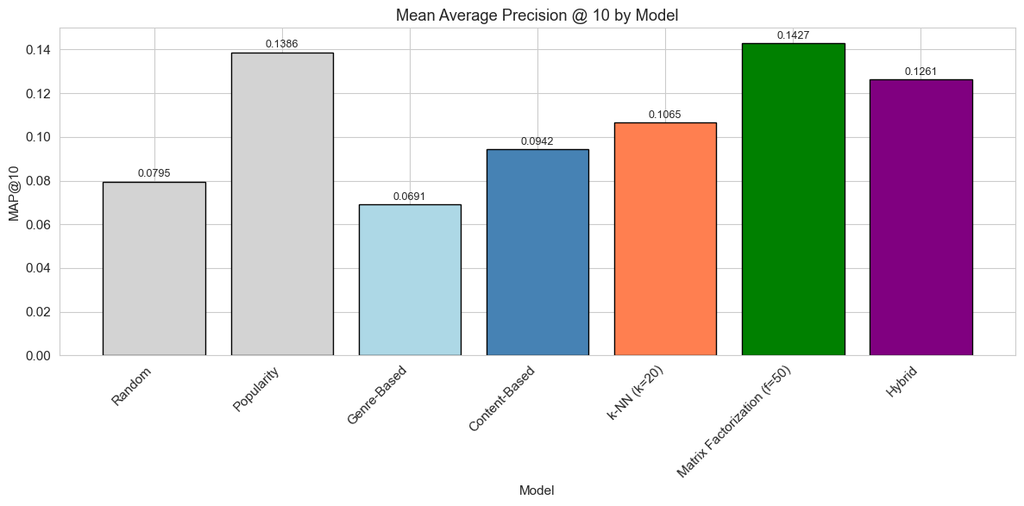

```
Saved: results/diagrams/model_comparison_map10.png
```

```python
# Bar chart comparing MAP@10 across models
plt.figure(figsize=(12, 6))
models = list(all_results.keys())
map_scores = [all_results[m]['MAP@10'] for m in models]

colors = ['lightgray', 'lightgray', 'lightblue', 'steelblue', 'coral', 'green', 'purple']
bars = plt.bar(models, map_scores, color=colors, edgecolor='black')
plt.xlabel('Model')
plt.ylabel('MAP@10')
plt.title('Mean Average Precision @ 10 by Model')
plt.xticks(rotation=45, ha='right')

# Add value labels on bars
for bar, score in zip(bars, map_scores):
    plt.text(bar.get_x() + bar.get_width()/2, bar.get_height() + 0.001,
             f'{score:.4f}', ha='center', va='bottom', fontsize=9)

plt.tight_layout()
plt.savefig(os.path.join(DIAGRAMS_DIR, 'model_comparison_map10.png'), dpi=150, bbox_inches='tight')
plt.show()
print(f"Saved: {DIAGRAMS_DIR}/model_comparison_map10.png")
```

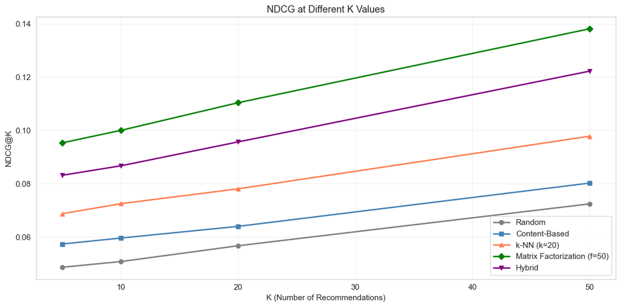

```
Saved: results/diagrams/ndcg_vs_k.png
```

```python
# Line chart showing performance at different K values
plt.figure(figsize=(12, 6))
k_values = [5, 10, 20, 50]

# Select key models to display
key_models = ['Random', 'Content-Based', 'k-NN (k=20)', 'Matrix Factorization (f=50)', 'Hybrid']
markers = ['o', 's', '^', 'D', 'v']
colors = ['gray', 'steelblue', 'coral', 'green', 'purple']

for model, marker, color in zip(key_models, markers, colors):
    if model in all_results:
        ndcg_values = [all_results[model][f'NDCG@{k}'] for k in k_values]
        plt.plot(k_values, ndcg_values, marker=marker, label=model, color=color, linewidth=2)

plt.xlabel('K (Number of Recommendations)')
plt.ylabel('NDCG@K')
plt.title('NDCG at Different K Values')
plt.legend(loc='lower right')
plt.grid(True, alpha=0.3)
plt.tight_layout()
plt.savefig(os.path.join(DIAGRAMS_DIR, 'ndcg_vs_k.png'), dpi=150, bbox_inches='tight')
plt.show()
print(f"Saved: {DIAGRAMS_DIR}/ndcg_vs_k.png")
```

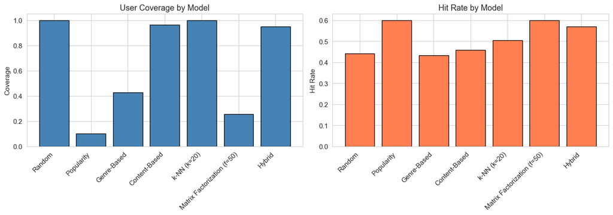

```
Saved: results/diagrams/coverage_hitrate.png
```

```python
# Coverage and Hit Rate comparison
fig, axes = plt.subplots(1, 2, figsize=(14, 5))

# Coverage
ax1 = axes[0]
coverage = [all_results[m]['Coverage'] for m in models]
ax1.bar(models, coverage, color='steelblue', edgecolor='black')
ax1.set_ylabel('Coverage')
ax1.set_title('User Coverage by Model')
ax1.set_xticklabels(models, rotation=45, ha='right')

# Hit Rate
ax2 = axes[1]
hit_rates = [all_results[m]['Hit_Rate'] for m in models]
ax2.bar(models, hit_rates, color='coral', edgecolor='black')
ax2.set_ylabel('Hit Rate')
ax2.set_title('Hit Rate by Model')
ax2.set_xticklabels(models, rotation=45, ha='right')

plt.tight_layout()
plt.savefig(os.path.join(DIAGRAMS_DIR, 'coverage_hitrate.png'), dpi=150, bbox_inches='tight')
plt.show()
print(f"Saved: {DIAGRAMS_DIR}/coverage_hitrate.png")
```

### DEMONSTRATION FUNCTION

```python
def demonstrate_recommendation(song_idx, recommender, df, user_profiles, k=10):
    """
    Demonstrate the recommendation system for a given song.
    Shows song details, recommended users, and their profiles.
    """
    # Get song details
    song = df.loc[song_idx]

    print("=" * 70)
    print("SONG DETAILS")
    print("=" * 70)
    print(f"Title: {song['title']}")
    print(f"Artist: {song['artist_name']}")
    print(f"Genre: {song['genres']}")
    print(f"Complexity: {song['complexity']:.3f}")
    print(f"Pitch Class Entropy: {song['pitch_class_entropy']:.3f}")
    print(f"Scale Consistency: {song['scale_consistency']:.3f}")
    print(f"Groove Consistency: {song['groove_consistency']:.3f}")
    if song['is_rated']:
        print(f"Rating: {song['rating']:.2f}")

    print("\n" + "=" * 70)
    print(f"TOP {k} RECOMMENDED USERS (using {recommender.name})")
    print("=" * 70)

    # Get recommendations
    scored = recommender.score_users(song_idx)
    top_k = scored[:k]

    # Create lookup for user profiles
    user_profile_dict = {u['user_id']: u for u in user_profiles}

    for rank, (user_id, score) in enumerate(top_k, 1):
        profile = user_profile_dict[user_id]
        print(f"\n{rank}. {user_id} (Score: {score:.4f})")
        print(f"   Archetype: {profile['archetype']}")
        print(f"   Preferred Genres: {', '.join(profile['preferred_genres'])}")
        print(f"   Prefs: Complexity={profile['pref_complexity']:.2f}, "
              f"Entropy={profile['pref_entropy']:.2f}, "
              f"Scale={profile['pref_scale']:.2f}, "
              f"Groove={profile['pref_groove']:.2f}")

    return top_k
```

```python
# Run demonstration on a sample test song
print("\n" + "=" * 70)
print("DEMONSTRATION: Song-to-User Recommendation")
print("=" * 70)

# Pick a random test song with good features
sample_song_idx = test_songs[0]
demonstrate_recommendation(sample_song_idx, hybrid_rec, df, USER_PROFILES, k=5)
```

```
======================================================================
DEMONSTRATION: Song-to-User Recommendation
======================================================================
======================================================================
SONG DETAILS
======================================================================
Title: Turkish March - Beethoven (Arr. by Anton Rubistein)
Artist: Wolfgang Amadeus Mozart
Genre: classical
Complexity: 2.000
Pitch Class Entropy: 2.889
Scale Consistency: 0.923
Groove Consistency: 0.966
Rating: 4.88

======================================================================
TOP 5 RECOMMENDED USERS (using Hybrid)
======================================================================

1. user_0466 (Score: 0.8187)
   Archetype: Electronic Explorer
   Preferred Genres: electronic
   Prefs: Complexity=0.32, Entropy=0.75, Scale=0.80, Groove=0.97

2. user_0197 (Score: 0.8082)
   Archetype: Rhythm Focused
   Preferred Genres: electronic, rock
   Prefs: Complexity=0.50, Entropy=0.77, Scale=0.70, Groove=1.00

3. user_0280 (Score: 0.7890)
   Archetype: Classical Purist
   Preferred Genres: classical
   Prefs: Complexity=0.58, Entropy=0.85, Scale=0.70, Groove=0.90

4. user_0457 (Score: 0.7875)
   Archetype: Classical Purist
   Preferred Genres: classical
   Prefs: Complexity=0.72, Entropy=0.72, Scale=0.98, Groove=0.66

5. user_0306 (Score: 0.7806)
   Archetype: Rhythm Focused
   Preferred Genres: electronic, rock
   Prefs: Complexity=0.51, Entropy=0.87, Scale=0.81, Groove=0.94
```

```
[('user_0466', np.float64(0.818712605095373)),
 ('user_0197', np.float64(0.8082211109236752)),
 ('user_0280', np.float64(0.7890466070284011)),
 ('user_0457', np.float64(0.7874953424804783)),
 ('user_0306', np.float64(0.7805515514964987))]
```

```python
# Additional demonstration with different song
print("\n\n")
sample_song_idx2 = test_songs[100] if len(test_songs) > 100 else test_songs[-1]
demonstrate_recommendation(sample_song_idx2, hybrid_rec, df, USER_PROFILES, k=5)
```

```
======================================================================
SONG DETAILS
======================================================================
Title: FISHERS' HORNPIPE
Artist: Misc tunes
Genre: Unknown
Complexity: 1.000
Pitch Class Entropy: 2.797
Scale Consistency: 0.992
Groove Consistency: 0.946

======================================================================
TOP 5 RECOMMENDED USERS (using Hybrid)
======================================================================

1. user_0075 (Score: 0.7983)
   Archetype: Folk Fan
   Preferred Genres: folk
   Prefs: Complexity=0.40, Entropy=0.85, Scale=0.95, Groove=0.82

2. user_0454 (Score: 0.7738)
   Archetype: Rock Aficionado
   Preferred Genres: rock
   Prefs: Complexity=0.78, Entropy=0.73, Scale=0.76, Groove=1.00

3. user_0420 (Score: 0.7549)
   Archetype: Rock Aficionado
   Preferred Genres: rock
   Prefs: Complexity=0.57, Entropy=0.79, Scale=1.00, Groove=1.00

4. user_0429 (Score: 0.7449)
   Archetype: Rock Aficionado
   Preferred Genres: rock
   Prefs: Complexity=0.70, Entropy=0.65, Scale=0.70, Groove=0.99

5. user_0054 (Score: 0.6997)
   Archetype: Folk Fan
   Preferred Genres: folk
   Prefs: Complexity=0.41, Entropy=0.55, Scale=0.66, Groove=0.64
```

```
[('user_0075', np.float64(0.7983166376233337)),
 ('user_0454', np.float64(0.7738494962805712)),
 ('user_0420', np.float64(0.7548577572365552)),
 ('user_0429', np.float64(0.7448809831057129)),
 ('user_0054', np.float64(0.6997398458070495))]
```

## Section 5: Discussion of Related Work

### Prior Work on the PDMX Dataset

The PDMX paper itself focuses primarily on music generation tasks rather than recommendation:

- Unconditional multitrack music generation using transformer-based models
- Analysis of how data quality (ratings) affects generation quality
- Deduplication strategies for symbolic music

### Related Work on Music Recommendation

1. **Content-Based Filtering (CBF):**
   - Uses audio features (MFCCs, spectral features) for similarity
   - Our approach uses symbolic music features (complexity, entropy, etc.)
2. **Collaborative Filtering:**
   - Matrix Factorization (Koren et al., Netflix Prize)
   - Our SVD-based approach follows this tradition
3. **Hybrid Systems:**
   - Spotify's approach combines content and collaborative signals
   - Our hybrid model combines content-based, k-NN, and MF
4. **Cold-Start Problem:**
   - Critical challenge in music recommendation
   - Our content-to-factor mapping addresses this for new songs